# Risk Factor Analysis

## Outcome Variable

**Outcome Variable:** ever_stunted

## Predictor Variables

**Intervention Variable:** tr

**Adjustment Set:**

unadjusted

## Stratifying Variables

The analysis was stratified on these variable(s):

- pers_wast
- agecat
- studyid
- country

## Data Summary

| pers_wast | agecat | studyid | country | tr | ever_stunted | n_cell | n |
| --- | --- | --- | --- | --- | --- | --- | --- |
| 0 | 0-6 months | ki1017093b-PROVIDE | BANGLADESH | Control | 0 | 140 | 625 |
| 0 | 0-6 months | ki1017093b-PROVIDE | BANGLADESH | Control | 1 | 23 | 625 |
| 0 | 0-6 months | ki1017093b-PROVIDE | BANGLADESH | Other | 0 | 400 | 625 |
| 0 | 0-6 months | ki1017093b-PROVIDE | BANGLADESH | Other | 1 | 62 | 625 |
| 1 | 0-6 months | ki1017093b-PROVIDE | BANGLADESH | Control | 0 | 2 | 15 |
| 1 | 0-6 months | ki1017093b-PROVIDE | BANGLADESH | Control | 1 | 1 | 15 |
| 1 | 0-6 months | ki1017093b-PROVIDE | BANGLADESH | Other | 0 | 9 | 15 |
| 1 | 0-6 months | ki1017093b-PROVIDE | BANGLADESH | Other | 1 | 3 | 15 |
| 0 | 0-6 months | ki1066203-TanzaniaChild2 | TANZANIA, UNITED REPUBLIC OF | Control | 0 | 503 | 2181 |
| 0 | 0-6 months | ki1066203-TanzaniaChild2 | TANZANIA, UNITED REPUBLIC OF | Control | 1 | 40 | 2181 |
| 0 | 0-6 months | ki1066203-TanzaniaChild2 | TANZANIA, UNITED REPUBLIC OF | Other | 0 | 505 | 2181 |
| 0 | 0-6 months | ki1066203-TanzaniaChild2 | TANZANIA, UNITED REPUBLIC OF | Other | 1 | 35 | 2181 |
| 0 | 0-6 months | ki1066203-TanzaniaChild2 | TANZANIA, UNITED REPUBLIC OF | Zinc | 0 | 1017 | 2181 |
| 0 | 0-6 months | ki1066203-TanzaniaChild2 | TANZANIA, UNITED REPUBLIC OF | Zinc | 1 | 81 | 2181 |
| 1 | 0-6 months | ki1066203-TanzaniaChild2 | TANZANIA, UNITED REPUBLIC OF | Control | 0 | 14 | 53 |
| 1 | 0-6 months | ki1066203-TanzaniaChild2 | TANZANIA, UNITED REPUBLIC OF | Control | 1 | 0 | 53 |
| 1 | 0-6 months | ki1066203-TanzaniaChild2 | TANZANIA, UNITED REPUBLIC OF | Other | 0 | 14 | 53 |
| 1 | 0-6 months | ki1066203-TanzaniaChild2 | TANZANIA, UNITED REPUBLIC OF | Other | 1 | 1 | 53 |
| 1 | 0-6 months | ki1066203-TanzaniaChild2 | TANZANIA, UNITED REPUBLIC OF | Zinc | 0 | 22 | 53 |
| 1 | 0-6 months | ki1066203-TanzaniaChild2 | TANZANIA, UNITED REPUBLIC OF | Zinc | 1 | 2 | 53 |
| 0 | 0-6 months | ki1112895-Guatemala BSC | GUATEMALA | Control | 0 | 90 | 235 |
| 0 | 0-6 months | ki1112895-Guatemala BSC | GUATEMALA | Control | 1 | 28 | 235 |
| 0 | 0-6 months | ki1112895-Guatemala BSC | GUATEMALA | Other | 0 | 93 | 235 |
| 0 | 0-6 months | ki1112895-Guatemala BSC | GUATEMALA | Other | 1 | 24 | 235 |
| 1 | 0-6 months | ki1112895-Guatemala BSC | GUATEMALA | Control | 0 | 0 | 6 |
| 1 | 0-6 months | ki1112895-Guatemala BSC | GUATEMALA | Control | 1 | 2 | 6 |
| 1 | 0-6 months | ki1112895-Guatemala BSC | GUATEMALA | Other | 0 | 3 | 6 |
| 1 | 0-6 months | ki1112895-Guatemala BSC | GUATEMALA | Other | 1 | 1 | 6 |
| 0 | 6-24 months | ki1017093b-PROVIDE | BANGLADESH | Control | 0 | 100 | 488 |
| 0 | 6-24 months | ki1017093b-PROVIDE | BANGLADESH | Control | 1 | 24 | 488 |

[output cut: 52 more lines]

The following strata were considered:

- pers_wast: 0, agecat: 0-24 months, studyid: ki1017093b-PROVIDE, country: BANGLADESH
- pers_wast: 0, agecat: 0-24 months, studyid: ki1066203-TanzaniaChild2, country: TANZANIA, UNITED REPUBLIC OF
- pers_wast: 0, agecat: 0-24 months, studyid: ki1112895-Guatemala BSC, country: GUATEMALA
- pers_wast: 0, agecat: 0-6 months, studyid: ki1017093b-PROVIDE, country: BANGLADESH
- pers_wast: 0, agecat: 0-6 months, studyid: ki1066203-TanzaniaChild2, country: TANZANIA, UNITED REPUBLIC OF
- pers_wast: 0, agecat: 0-6 months, studyid: ki1112895-Guatemala BSC, country: GUATEMALA
- pers_wast: 0, agecat: 6-24 months, studyid: ki1017093b-PROVIDE, country: BANGLADESH
- pers_wast: 0, agecat: 6-24 months, studyid: ki1066203-TanzaniaChild2, country: TANZANIA, UNITED REPUBLIC OF
- pers_wast: 0, agecat: 6-24 months, studyid: ki1112895-Guatemala BSC, country: GUATEMALA
- pers_wast: 1, agecat: 0-24 months, studyid: ki1017093b-PROVIDE, country: BANGLADESH
- pers_wast: 1, agecat: 0-24 months, studyid: ki1066203-TanzaniaChild2, country: TANZANIA, UNITED REPUBLIC OF
- pers_wast: 1, agecat: 0-24 months, studyid: ki1112895-Guatemala BSC, country: GUATEMALA
- pers_wast: 1, agecat: 0-6 months, studyid: ki1017093b-PROVIDE, country: BANGLADESH
- pers_wast: 1, agecat: 0-6 months, studyid: ki1066203-TanzaniaChild2, country: TANZANIA, UNITED REPUBLIC OF
- pers_wast: 1, agecat: 0-6 months, studyid: ki1112895-Guatemala BSC, country: GUATEMALA
- pers_wast: 1, agecat: 6-24 months, studyid: ki1017093b-PROVIDE, country: BANGLADESH
- pers_wast: 1, agecat: 6-24 months, studyid: ki1066203-TanzaniaChild2, country: TANZANIA, UNITED REPUBLIC OF
- pers_wast: 1, agecat: 6-24 months, studyid: ki1112895-Guatemala BSC, country: GUATEMALA

### Dropped Strata

Some strata were dropped due to rare outcomes:

- pers_wast: 1, agecat: 0-6 months, studyid: ki1017093b-PROVIDE, country: BANGLADESH
- pers_wast: 1, agecat: 0-6 months, studyid: ki1066203-TanzaniaChild2, country: TANZANIA, UNITED REPUBLIC OF
- pers_wast: 1, agecat: 0-6 months, studyid: ki1112895-Guatemala BSC, country: GUATEMALA
- pers_wast: 1, agecat: 6-24 months, studyid: ki1017093b-PROVIDE, country: BANGLADESH
- pers_wast: 1, agecat: 6-24 months, studyid: ki1066203-TanzaniaChild2, country: TANZANIA, UNITED REPUBLIC OF
- pers_wast: 1, agecat: 6-24 months, studyid: ki1112895-Guatemala BSC, country: GUATEMALA
- pers_wast: 1, agecat: 0-24 months, studyid: ki1017093b-PROVIDE, country: BANGLADESH
- pers_wast: 1, agecat: 0-24 months, studyid: ki1066203-TanzaniaChild2, country: TANZANIA, UNITED REPUBLIC OF
- pers_wast: 1, agecat: 0-24 months, studyid: ki1112895-Guatemala BSC, country: GUATEMALA

## Methods Detail

We’re interested in the causal parameters $E[Y_a]$ for all values of $a \in \mathcal{A}$. These parameters represent the mean outcome if, possibly contrary to fact, we intervened to set all units to have $A=a$. Under the randomization and positivity assumptions, these are identified by the statistical parameters $\psi_a=E_W[E_{Y|A,W}(Y|A=a,W)]$. In addition, we’re interested in the mean of $Y$, $E[Y]$ under no intervention (the observed mean). We will estimate these parameters by using SuperLearner to fit the relevant likelihood factors – $E_{Y|A,W}(Y|A=a,W)$ and $p(A=a|W)$, and then updating our likelihood fit using a joint TMLE.

For unadjusted analyses ($W=\{\}$), initial likelihoods were estimated using Lrnr_glm to estimate the simple $E(Y|A)$ and Lrnr_mean to estimate $p(A)$. For adjusted analyses, a small library containing Lrnr_glmnet, Lrnr_xgboost, and Lrnr_mean was used.

Having estimated these parameters, we will then use the delta method to estimate relative risks and attributable risks relative to a prespecified baseline level of $A$.

# Results Detail

## Results Plots

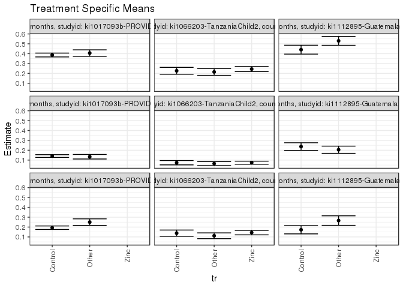

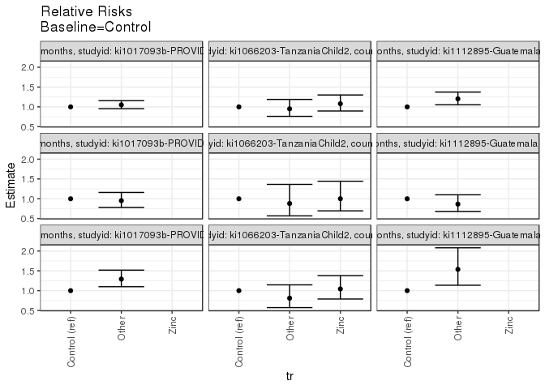

[figure not shown]

[figure not shown]

## Results Table

### Parameter: TSM

| pers_wast | agecat | studyid | country | intervention_level | baseline_level | estimate | ci_lower | ci_upper |
| --- | --- | --- | --- | --- | --- | --- | --- | --- |
| 0 | 0-24 months | ki1017093b-PROVIDE | BANGLADESH | Control | NA | 0.3865031 | 0.3670227 | 0.4059834 |
| 0 | 0-24 months | ki1017093b-PROVIDE | BANGLADESH | Other | NA | 0.4060475 | 0.3729363 | 0.4391588 |
| 0 | 0-24 months | ki1066203-TanzaniaChild2 | TANZANIA, UNITED REPUBLIC OF | Control | NA | 0.2262774 | 0.1912369 | 0.2613178 |
| 0 | 0-24 months | ki1066203-TanzaniaChild2 | TANZANIA, UNITED REPUBLIC OF | Other | NA | 0.2150735 | 0.1805389 | 0.2496082 |
| 0 | 0-24 months | ki1066203-TanzaniaChild2 | TANZANIA, UNITED REPUBLIC OF | Zinc | NA | 0.2441441 | 0.2188670 | 0.2694213 |
| 0 | 0-24 months | ki1112895-Guatemala BSC | GUATEMALA | Control | NA | 0.4406780 | 0.3956026 | 0.4857533 |
| 0 | 0-24 months | ki1112895-Guatemala BSC | GUATEMALA | Other | NA | 0.5299145 | 0.4847923 | 0.5750368 |
| 0 | 0-6 months | ki1017093b-PROVIDE | BANGLADESH | Control | NA | 0.1411043 | 0.1271551 | 0.1550535 |
| 0 | 0-6 months | ki1017093b-PROVIDE | BANGLADESH | Other | NA | 0.1341991 | 0.1112048 | 0.1571935 |
| 0 | 0-6 months | ki1066203-TanzaniaChild2 | TANZANIA, UNITED REPUBLIC OF | Control | NA | 0.0736648 | 0.0516882 | 0.0956415 |
| 0 | 0-6 months | ki1066203-TanzaniaChild2 | TANZANIA, UNITED REPUBLIC OF | Other | NA | 0.0648148 | 0.0440448 | 0.0855848 |
| 0 | 0-6 months | ki1066203-TanzaniaChild2 | TANZANIA, UNITED REPUBLIC OF | Zinc | NA | 0.0737705 | 0.0583056 | 0.0892354 |
| 0 | 0-6 months | ki1112895-Guatemala BSC | GUATEMALA | Control | NA | 0.2372881 | 0.1986634 | 0.2759129 |
| 0 | 0-6 months | ki1112895-Guatemala BSC | GUATEMALA | Other | NA | 0.2051282 | 0.1686225 | 0.2416339 |
| 0 | 6-24 months | ki1017093b-PROVIDE | BANGLADESH | Control | NA | 0.1935484 | 0.1758608 | 0.2112360 |
| 0 | 6-24 months | ki1017093b-PROVIDE | BANGLADESH | Other | NA | 0.2500000 | 0.2167857 | 0.2832143 |
| 0 | 6-24 months | ki1066203-TanzaniaChild2 | TANZANIA, UNITED REPUBLIC OF | Control | NA | 0.1381579 | 0.1064777 | 0.1698381 |
| 0 | 6-24 months | ki1066203-TanzaniaChild2 | TANZANIA, UNITED REPUBLIC OF | Other | NA | 0.1118568 | 0.0826296 | 0.1410840 |
| 0 | 6-24 months | ki1066203-TanzaniaChild2 | TANZANIA, UNITED REPUBLIC OF | Zinc | NA | 0.1441242 | 0.1211976 | 0.1670507 |
| 0 | 6-24 months | ki1112895-Guatemala BSC | GUATEMALA | Control | NA | 0.1728395 | 0.1310229 | 0.2146561 |
| 0 | 6-24 months | ki1112895-Guatemala BSC | GUATEMALA | Other | NA | 0.2658228 | 0.2175725 | 0.3140730 |

### Parameter: E(Y)

| pers_wast | agecat | studyid | country | intervention_level | baseline_level | estimate | ci_lower | ci_upper |
| --- | --- | --- | --- | --- | --- | --- | --- | --- |
| 0 | 0-24 months | ki1017093b-PROVIDE | BANGLADESH | NA | NA | 0.4009585 | 0.3625359 | 0.4393810 |
| 0 | 0-24 months | ki1066203-TanzaniaChild2 | TANZANIA, UNITED REPUBLIC OF | NA | NA | 0.2325159 | 0.2148677 | 0.2501640 |
| 0 | 0-24 months | ki1112895-Guatemala BSC | GUATEMALA | NA | NA | 0.4851064 | 0.4210714 | 0.5491414 |
| 0 | 0-6 months | ki1017093b-PROVIDE | BANGLADESH | NA | NA | 0.1360000 | 0.1091043 | 0.1628957 |
| 0 | 0-6 months | ki1066203-TanzaniaChild2 | TANZANIA, UNITED REPUBLIC OF | NA | NA | 0.0715268 | 0.0607090 | 0.0823446 |
| 0 | 0-6 months | ki1112895-Guatemala BSC | GUATEMALA | NA | NA | 0.2212766 | 0.1680903 | 0.2744629 |
| 0 | 6-24 months | ki1017093b-PROVIDE | BANGLADESH | NA | NA | 0.2356557 | 0.1979622 | 0.2733493 |
| 0 | 6-24 months | ki1066203-TanzaniaChild2 | TANZANIA, UNITED REPUBLIC OF | NA | NA | 0.1346260 | 0.1188755 | 0.1503766 |
| 0 | 6-24 months | ki1112895-Guatemala BSC | GUATEMALA | NA | NA | 0.2187500 | 0.1544933 | 0.2830067 |

### Parameter: RR

| pers_wast | agecat | studyid | country | intervention_level | baseline_level | estimate | ci_lower | ci_upper |
| --- | --- | --- | --- | --- | --- | --- | --- | --- |
| 0 | 0-24 months | ki1017093b-PROVIDE | BANGLADESH | Control | Control | 1.0000000 | 1.0000000 | 1.000000 |
| 0 | 0-24 months | ki1017093b-PROVIDE | BANGLADESH | Other | Control | 1.0505674 | 0.9545322 | 1.156265 |
| 0 | 0-24 months | ki1066203-TanzaniaChild2 | TANZANIA, UNITED REPUBLIC OF | Control | Control | 1.0000000 | 1.0000000 | 1.000000 |
| 0 | 0-24 months | ki1066203-TanzaniaChild2 | TANZANIA, UNITED REPUBLIC OF | Other | Control | 0.9504862 | 0.7604391 | 1.188030 |
| 0 | 0-24 months | ki1066203-TanzaniaChild2 | TANZANIA, UNITED REPUBLIC OF | Zinc | Control | 1.0789596 | 0.8955823 | 1.299885 |
| 0 | 0-24 months | ki1112895-Guatemala BSC | GUATEMALA | Control | Control | 1.0000000 | 1.0000000 | 1.000000 |
| 0 | 0-24 months | ki1112895-Guatemala BSC | GUATEMALA | Other | Control | 1.2024984 | 1.0526503 | 1.373678 |
| 0 | 0-6 months | ki1017093b-PROVIDE | BANGLADESH | Control | Control | 1.0000000 | 1.0000000 | 1.000000 |
| 0 | 0-6 months | ki1017093b-PROVIDE | BANGLADESH | Other | Control | 0.9510634 | 0.7803660 | 1.159099 |
| 0 | 0-6 months | ki1066203-TanzaniaChild2 | TANZANIA, UNITED REPUBLIC OF | Control | Control | 1.0000000 | 1.0000000 | 1.000000 |
| 0 | 0-6 months | ki1066203-TanzaniaChild2 | TANZANIA, UNITED REPUBLIC OF | Other | Control | 0.8798611 | 0.5678956 | 1.363201 |
| 0 | 0-6 months | ki1066203-TanzaniaChild2 | TANZANIA, UNITED REPUBLIC OF | Zinc | Control | 1.0014344 | 0.6954547 | 1.442036 |
| 0 | 0-6 months | ki1112895-Guatemala BSC | GUATEMALA | Control | Control | 1.0000000 | 1.0000000 | 1.000000 |
| 0 | 0-6 months | ki1112895-Guatemala BSC | GUATEMALA | Other | Control | 0.8644689 | 0.6792137 | 1.100252 |
| 0 | 6-24 months | ki1017093b-PROVIDE | BANGLADESH | Control | Control | 1.0000000 | 1.0000000 | 1.000000 |
| 0 | 6-24 months | ki1017093b-PROVIDE | BANGLADESH | Other | Control | 1.2916667 | 1.0993079 | 1.517685 |
| 0 | 6-24 months | ki1066203-TanzaniaChild2 | TANZANIA, UNITED REPUBLIC OF | Control | Control | 1.0000000 | 1.0000000 | 1.000000 |
| 0 | 6-24 months | ki1066203-TanzaniaChild2 | TANZANIA, UNITED REPUBLIC OF | Other | Control | 0.8096303 | 0.5718849 | 1.146212 |
| 0 | 6-24 months | ki1066203-TanzaniaChild2 | TANZANIA, UNITED REPUBLIC OF | Zinc | Control | 1.0431845 | 0.7891480 | 1.378998 |
| 0 | 6-24 months | ki1112895-Guatemala BSC | GUATEMALA | Control | Control | 1.0000000 | 1.0000000 | 1.000000 |
| 0 | 6-24 months | ki1112895-Guatemala BSC | GUATEMALA | Other | Control | 1.5379747 | 1.1365617 | 2.081159 |

### Parameter: PAR

| pers_wast | agecat | studyid | country | intervention_level | baseline_level | estimate | ci_lower | ci_upper |
| --- | --- | --- | --- | --- | --- | --- | --- | --- |
| 0 | 0-24 months | ki1017093b-PROVIDE | BANGLADESH | Control | NA | 0.0144554 | -0.0186627 | 0.0475735 |
| 0 | 0-24 months | ki1066203-TanzaniaChild2 | TANZANIA, UNITED REPUBLIC OF | Control | NA | 0.0062385 | -0.0242272 | 0.0367043 |
| 0 | 0-24 months | ki1112895-Guatemala BSC | GUATEMALA | Control | NA | 0.0444284 | -0.0010545 | 0.0899113 |
| 0 | 0-6 months | ki1017093b-PROVIDE | BANGLADESH | Control | NA | -0.0051043 | -0.0280998 | 0.0178913 |
| 0 | 0-6 months | ki1066203-TanzaniaChild2 | TANZANIA, UNITED REPUBLIC OF | Control | NA | -0.0021380 | -0.0210987 | 0.0168227 |
| 0 | 0-6 months | ki1112895-Guatemala BSC | GUATEMALA | Control | NA | -0.0160115 | -0.0525753 | 0.0205522 |
| 0 | 6-24 months | ki1017093b-PROVIDE | BANGLADESH | Control | NA | 0.0421074 | 0.0088214 | 0.0753933 |
| 0 | 6-24 months | ki1066203-TanzaniaChild2 | TANZANIA, UNITED REPUBLIC OF | Control | NA | -0.0035319 | -0.0308195 | 0.0237558 |
| 0 | 6-24 months | ki1112895-Guatemala BSC | GUATEMALA | Control | NA | 0.0459105 | -0.0028778 | 0.0946988 |

### Parameter: PAF

| pers_wast | agecat | studyid | country | intervention_level | baseline_level | estimate | ci_lower | ci_upper |
| --- | --- | --- | --- | --- | --- | --- | --- | --- |
| 0 | 0-24 months | ki1017093b-PROVIDE | BANGLADESH | Control | NA | 0.0360521 | -0.0469689 | 0.1124899 |
| 0 | 0-24 months | ki1066203-TanzaniaChild2 | TANZANIA, UNITED REPUBLIC OF | Control | NA | 0.0268305 | -0.1134187 | 0.1494136 |
| 0 | 0-24 months | ki1112895-Guatemala BSC | GUATEMALA | Control | NA | 0.0915849 | 0.0018267 | 0.1732718 |
| 0 | 0-6 months | ki1017093b-PROVIDE | BANGLADESH | Control | NA | -0.0375316 | -0.2287164 | 0.1239054 |
| 0 | 0-6 months | ki1066203-TanzaniaChild2 | TANZANIA, UNITED REPUBLIC OF | Control | NA | -0.0298909 | -0.3321751 | 0.2038019 |
| 0 | 0-6 months | ki1112895-Guatemala BSC | GUATEMALA | Control | NA | -0.0723598 | -0.2655680 | 0.0913522 |
| 0 | 6-24 months | ki1017093b-PROVIDE | BANGLADESH | Control | NA | 0.1786816 | 0.0531888 | 0.2875413 |
| 0 | 6-24 months | ki1066203-TanzaniaChild2 | TANZANIA, UNITED REPUBLIC OF | Control | NA | -0.0262346 | -0.2503099 | 0.1576829 |
| 0 | 6-24 months | ki1112895-Guatemala BSC | GUATEMALA | Control | NA | 0.2098765 | 0.0068033 | 0.3714285 |